# Homework 3: Modelling Frame and FISHNET Construction

Eli Polzer, Matt Futia, and Amelia McReynolds

12 February 2021

```r
# some libraries
  library(raster)   # FXNS: extent, raster, res, rasterize, values, writeRaster,
                    #       cellFromXY, extract
  library(sf)       # FXNS: st_as_sf, st_as_sfc, st_bbox, st_convex_hull, st_union
                    #       st_buffer, st_read, st_write, st_intersection, st_geometry,
                    #       st_drop_geometry, st_coordinates, st_sf
  library(terra)    # FXNS: as.data.frame, rast, vect
  library(readr)
  library(ggplot2)
  library(dplyr)
  library(tidyr)
```

## This exercise links to Module 2.3.4

Submit the completed exercise to us at:

- t.edwards@usu.edu
- eric_tsakiris@fws.gov

## Context

The Uinta Basin hookless cactus (*Sclerocactus wetlandicus*) (SCWE) is listed as a threatened species. Recovery goals require: * An accurate range map; * Comprehensive surveys on locations; and * Other needs as well [FWS ECOS](https://ecos.fws.gov/ecp/species/9037) has an expert opinion-based “blob” of an hypothetical SCWE modelling (ie, the “blob”) domain.

## The Data

- Acquire from the ECOS site the SCWE “blob” shapefile (call it: scwe_ecospoly)
- Import the **`scwe_pres.csv`** file of known SCWE presence points
- Data in: **`~\sdhmR-V2020.2\data\gis_layers`** and **`...\module02`**, respectively

## Question #1

- Import the ECOS–acquired SCWE “blob” as a spatial object (call it: **`scwe_ecospoly`**)
- Find and acquire the **`CRS epsg:42303`** and it’s **`proj4string`** – this is the CRS for ALL subsequent analyses
- Set CRS of (i) the ECOS “blob” and (ii) the imported points to epsg:42303
- Plot the presence points relative to the ECOS-based polygon “blob”

```r
#import ECOS blob shapefile w/ sf package
scwe_ecospoly <- st_read("~/University of Vermont/Classes/sdhmR/sdhmR-V2021.1/data/gis_layers/scwe_ecospoly.shp")
#import presence points data w/ readr
scwe_pres <- read_csv("~/University of Vermont/Classes/sdhmR/sdhmR-V2021.1/data/module02/scwe_pres.csv",
     col_types = cols(date.r = col_date(format = "%Y-%m-%d")))
```

```r
#proj4string for epsg:42303 from https://epsg.io/42303
prj.epsg42303 <- "+proj=aea +lat_1=29.5 +lat_2=45.5 +lat_0=23 +lon_0=-96 +x_0=0 +y_0=0 +ellps=GRS80 +datum=NAD83 +units=m +no_defs no_defs"

#proj4string for the scwe_pres current CRS:  ALBERS NORTH AMERICA NAD83
#   https://epsg.io/5070
    prj.aeaN83 <- "+proj=aea +lat_1=29.5 +lat_2=45.5 +lat_0=23 +lon_0=-96 +x_0=0 +y_0=0 +ellps=GRS80 +towgs84=0,0,0,0,0,0,0 +units=m +no_defs" # epsg:42303


#set CRS of the ECOS "blob" to epsg:42303 -- convert from the current crs
  scwe_ecospoly_01 <- st_transform(scwe_ecospoly, crs = prj.epsg42303) # output pts as spatial
  st_crs(scwe_ecospoly_01)$proj4string # check crs
```

```
## [1] "+proj=aea +lat_0=23 +lon_0=-96 +lat_1=29.5 +lat_2=45.5 +x_0=0 +y_0=0 +datum=NAD83 +units=m +no_defs"
```

```r
#set CRS of the imported points to epsg:42303 - similar to CSV in m02.01-dataimport
pts.in <- st_as_sf(scwe_pres, coords = c("aeaN83_x", "aeaN83_y"),
    crs = prj.aeaN83, remove = F) # remove=F to retain input x,y
  st_crs(pts.in)$proj4string # check crs
```

```
## [1] "+proj=aea +lat_0=23 +lon_0=-96 +lat_1=29.5 +lat_2=45.5 +x_0=0 +y_0=0 +ellps=GRS80 +towgs84=0,0,0,0,0,0,0 +units=m +no_defs"
```

```r
  # transform to new crs -- convert from the current crs
  scwe_pres_01 <- st_transform(pts.in, crs = prj.epsg42303) # output pts as spatial
  st_crs(scwe_pres_01)$proj4string # check crs -looks good
```

```
## [1] "+proj=aea +lat_0=23 +lon_0=-96 +lat_1=29.5 +lat_2=45.5 +x_0=0 +y_0=0 +datum=NAD83 +units=m +no_defs"
```

```r
  # adding new geometry back into dataframe as columns
  coords <- data.frame(st_coordinates(scwe_pres_01)) # create df of new geometry
  names(coords) <- c("NAD83_x", "NAD83_y") # assign names
  scwe_pres_01 <- st_sf(data.frame(scwe_pres_01,coords)) # add columns
```

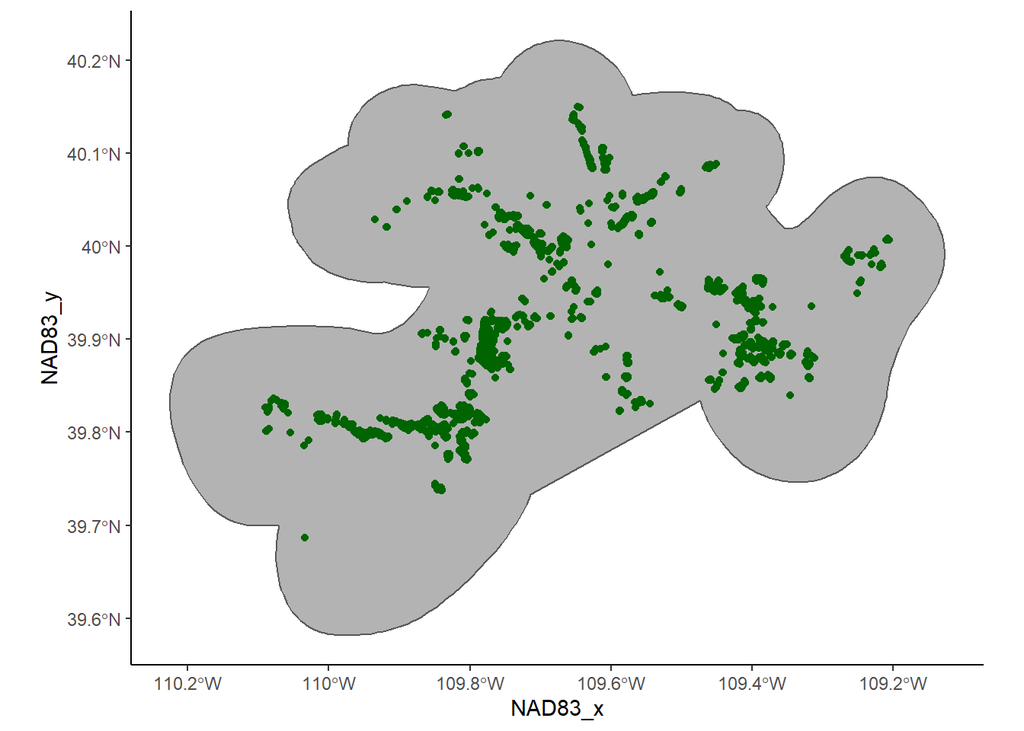

```r
# Plot the presence points relative to the ECOS-based polygon "blob"
ggplot() +
  geom_sf(data=scwe_ecospoly_01, fill="gray70") +
  geom_point(data=scwe_pres_01, aes(x=NAD83_x, y=NAD83_y), color="darkgreen") +
  theme_classic()
```

## Question #2

- Generate a buffered point-based (ie OPTION #4 from Mod 2.3.4) modelling frame
- Set buffer of 10,000 m
- Set CRS of modelling frame to epsg:42303

```r
# obtain desired crs for modelling frame & res from existing GIS data layer in NAD83 (epsg42303)
  t1 <- raster("~/University of Vermont/Classes/sdhmR/sdhmR-V2021.1/data/gis_layers/elev_1k_aea.img")
crs(t1)
```

```
## CRS arguments:
##  +proj=aea +lat_0=23 +lon_0=-96 +lat_1=29.5 +lat_2=45.5 +x_0=0 +y_0=0
## +datum=NAD83 +units=m +no_defs
```

```r
#make a buffered sf
scwe.bufptSF <- st_buffer(scwe_pres_01, dist = 10000) # 10,000 m buffer (units are meters)
  scwe.bufptSF <- st_union(scwe.bufptSF)  # merges all intersecting polys - usual for SDHM
  scwe.bufptSF # examine
```

```
## Geometry set for 1 feature
## geometry type:  POLYGON
## dimension:      XY
## bbox:           xmin: -1205096 ymin: 1933252 xmax: -1109030 ymax: 2005708
## CRS:            +proj=aea +lat_1=29.5 +lat_2=45.5 +lat_0=23 +lon_0=-96 +x_0=0 +y_0=0 +ellps=GRS80 +datum=NAD83 +units=m +no_defs no_defs
```

```r
# extract buffered points from template & rasterize
  scwe.bufptSP <- as_Spatial(scwe.bufptSF) # convert to sp spatialpolygon class
  scwe.bufptR <- crop(rasterize(scwe.bufptSP, t1), scwe.bufptSP) # t1 is template from above
  scwe.bufptR # examine
```

```
## class      : RasterLayer
## dimensions : 72, 96, 6912  (nrow, ncol, ncell)
## resolution : 1000, 1000  (x, y)
## extent     : -1205475, -1109475, 1933659, 2005659  (xmin, xmax, ymin, ymax)
## crs        : +proj=aea +lat_0=23 +lon_0=-96 +lat_1=29.5 +lat_2=45.5 +x_0=0 +y_0=0 +datum=NAD83 +units=m +no_defs
## source     : memory
## names      : layer
## values     : 1, 1  (min, max)
```

## Question #3

- Select larger of the two frames as FISHNET extent
  - (HINT: examine extents of both – one will be larger)

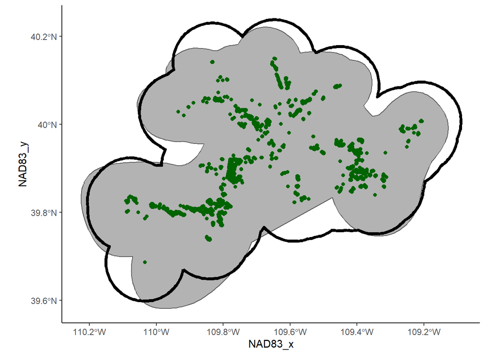

```r
  ggplot() +
  geom_sf(data=scwe_ecospoly_01,  fill="gray70") +
    geom_sf(data=scwe.bufptSF, color="black", lwd=1.5, fill=NA)+
  geom_point(data=scwe_pres_01, aes(x=NAD83_x, y=NAD83_y), color="darkgreen") +
  theme_classic()
```

```r
scwe.bufptSF
```

```
## Geometry set for 1 feature
## geometry type:  POLYGON
## dimension:      XY
## bbox:           xmin: -1205096 ymin: 1933252 xmax: -1109030 ymax: 2005708
## CRS:            +proj=aea +lat_1=29.5 +lat_2=45.5 +lat_0=23 +lon_0=-96 +x_0=0 +y_0=0 +ellps=GRS80 +datum=NAD83 +units=m +no_defs no_defs
```

```r
scwe_ecospoly
```

```
## Simple feature collection with 1 feature and 11 fields
## geometry type:  POLYGON
## dimension:      XY
## bbox:           xmin: -1206694 ymin: 1931294 xmax: -1112295 ymax: 2003811
## projected CRS:  NAD_1983_Albers
##   RANGE_ID                                        RANGE_COND ENTITY_ID SPCODE
## 1   174854 This range has not conditions associated with it.     10034   Q3N6
##   VIPCODE                     COMNAME                  SCINAME     POP_ABBREV
## 1     P01 Uinta Basin hookless cactus Sclerocactus wetlandicus Wherever found
##   STATUS_ABB    FAMILY SQmi                       geometry
## 1 Threatened Cactaceae    0 POLYGON ((-1150329 1997116,...
```

```r
((st_area(scwe.bufptSF) - st_area(scwe_ecospoly))/st_area(scwe_ecospoly))*100
```

```
## 10.8516 [1]
```

The frame created with 10 km-buffered points is 10.8% larger than the ECOS polygon, so I will use the buffered points shapefile as the FISHNET extent.

## Question #4

- Build a 1,000 m (1 km) square FISHNET
- Save both spatial and dataframe FISHNETs as R objects
  - (NOTE: we will use these later so be sure and save !!!)
- Export as both dataframe (ie, no geometry) and ESRI shapefile

```r
# extract coords, cell id of coords, & build dataframe
  f1 <- sp::coordinates(scwe.bufptR) # get spatial coords from scwe.bufptR
  f2 <- cellFromXY(scwe.bufptR, f1) # extract cell number from buffered extent
  f3 <- as.data.frame(cbind(f1, f2)) # build datframe of x,y & cell number
  head(f3, 2) # examine
```

```
##          x       y f2
## 1 -1204975 2005159  1
## 2 -1203975 2005159  2
```

```r
  tail(f3, 1) # f2 value should eq. ncell in scwe.bufptR; below
```

```
##             x       y   f2
## 6912 -1109975 1934159 6912
```

```r
  ncell(scwe.bufptR) # should eq. f2 value above
```

```
## [1] 6912
```

```r
# some dataframe clean-up
  names(f3)[1:3] <- c("cell.wgs_x", "cell.wgs_y", "FNETID") # assign names
  f3 <- f3[c("FNETID", "cell.wgs_x", "cell.wgs_y")] # reorder

# examine fishnet data structure
  dim(f3) # dimension; rows is maximum number of cells in fishnet
```

```
## [1] 6912    3
```

```r
  names(f3) # names in fishnet
```

```
## [1] "FNETID"     "cell.wgs_x" "cell.wgs_y"
```

```r
  head(f3, 2) # note first FNETID number
```

```
##   FNETID cell.wgs_x cell.wgs_y
## 1      1   -1204975    2005159
## 2      2   -1203975    2005159
```

```r
  tail(f3, 2) # note last FNETID number matches dimension size
```

```
##      FNETID cell.wgs_x cell.wgs_y
## 6911   6911   -1110975    1934159
## 6912   6912   -1109975    1934159
```

```r
# convert dataframe to spatial object
  scwe.fnetSF <- st_as_sf(f3, coords = c("cell.wgs_x", "cell.wgs_y"),
    crs = prj.epsg42303, remove = F) # remove=F retains input x,y)
  head(scwe.fnetSF, 2) # examine
```

```
## Simple feature collection with 2 features and 3 fields
## geometry type:  POINT
## dimension:      XY
## bbox:           xmin: -1204975 ymin: 2005159 xmax: -1203975 ymax: 2005159
## CRS:            +proj=aea +lat_1=29.5 +lat_2=45.5 +lat_0=23 +lon_0=-96 +x_0=0 +y_0=0 +ellps=GRS80 +datum=NAD83 +units=m +no_defs no_defs
##   FNETID cell.wgs_x cell.wgs_y                 geometry
## 1      1   -1204975    2005159 POINT (-1204975 2005159)
## 2      2   -1203975    2005159 POINT (-1203975 2005159)
```

```r
# build stand-alone dataframe from geospatial object
  class(scwe.fnetSF) # note dataframe class; will extract data.frame
```

```
## [1] "sf"         "data.frame"
```

```r
  scwe.fnetDF <- st_drop_geometry(scwe.fnetSF) # build dataframe
  head(scwe.fnetDF, 2) # examine
```

```
##   FNETID cell.wgs_x cell.wgs_y
## 1      1   -1204975    2005159
## 2      2   -1203975    2005159
```

```r
  class(scwe.fnetDF) # check if class=data.frame
```

```
## [1] "data.frame"
```

```r
# export as esri shapefile & dataframe
  setwd(path.mod2) # output path
  st_write(scwe.fnetSF, dsn = ".", layer = "scwe_fnetSF", driver = "ESRI Shapefile",
    delete_layer = T, delete_dsn = T) # output shapefile
```

```
## Deleting source `.' using driver `ESRI Shapefile'
## Writing layer `scwe_fnetSF' to data source `.' using driver `ESRI Shapefile'
## Writing 6912 features with 3 fields and geometry type Point.
```

```r
# save objects
  setwd(path.mod2) # output path
  save("scwe.fnetSF", "scwe.fnetDF", file = "scwe.fnet.RData")
```

## Question #5

Once you have completed the analyses above, answer the following:

- How do the known SCWE presences relate to the modelling frame “blob”?
- How different is the SCWE “blob” from a buffered point-based modelling domain?
- What is the best “blob” for creating a data indexing FISHNET? Why?

The known presences were used to create our modelling frame blob, so all known SCWE presences fell within the blob. We used a 10 km buffer around the points to make a FISHNET.

The ECOS polygon was similar to the buffered point-based modelling domain that we used, but was slightly (~10%) smaller and the boundaries were more irregular. Maybe it was traced by hand in ArcGIS?

Choosing the larger extent for a FISHNET is the best choice because it’s simpler to make a FISHNET smaller than make it larger, and greater environmental variability can be captured in the FISHNET. The best blob matches the objectives set out in your Intended Use Statement, and uses resolution that matches the resolution of your data somewhat closely. Sweeping points into a FISHNET obscures their specific location and reports them as a value assigned to a cell’s centroid, so it’s important to avoid losing too much resolution from your data.